Agrupamentos dos Estabelecimentos de Internação registrados no TABNET, São Paulo, entre 2020 e 2022, de acordo com a evolução da Covid19 Síndrome Respiratória Aguda Grave **Prevent Senior** *Sistema de Gestão da Qualidade* Última atualização em 24 / 10 / 2022 às 14:10 horas.

Abstract

# Introdução

O impacto global da Síndrome Respiratória Aguda Grave (SRAG) é difícil de estimar: fatores demográficos, culturais, econômicos e de saúde, diferenças nos sistemas de saúde entre os diversos países podem explicar algumas diferenças na sua incidência (VILLAR; BLANCO; KACMAREK, 2016).

A mortalidade geral por SRAG aproxima-se de 40-50% em todas as grandes séries descritas na literatura, embora vários estudos randomizados controlados relataram uma melhora na sobrevida em pacientes selecionados com SRAG (VILLAR; SULEMANJI; KACMAREK, 2014). A mortalidade hospitalar por SRAG moderada e grave ainda é superior a 40% (VILLAR; BLANCO; KACMAREK, 2016).

Este relatório tem por objetivo agrupar os estabelecimentos de internação registrados na Secretaria Municipal de Sáude de São Paulo em relação à idade dos pacientes no que diz respeito à Covid-19 com diagnóstico de SRAG, no período entre março de 2020 e setembro de 2022. Ou seja, segmentar os indivíduos (**estabelecimentos de internação**) com base nas características da faixa etária dos pacientes internados em suas dependências (**total de internados, número de óbitos, número de curados, taxa de óbitos**).

# Análise de agrupamentos

A análise de agrupamentos ou *clustering* é uma técnica cujo interesse é explorar informações em um conjunto de variáveis em análise. Os métodos de análise de agrupamento são **procedimentos estatísticos**, uma vez que a inclusão de novas variáveis ou de novos indivíduos pode modificar a formação dos *clusters* . Isto requer, obrigatoriamente, a elaboração de nova análise (FÁVERO; BELFIORE, 2017).

O principal objetivo desta técnica é agrupar os indivíduos em *clusters*, de tal forma que:

- Indivíduos de um mesmo *cluster* sejam semelhantes (**similares**) em relação aos valores das variáveis em análise.
- E em contrapartida, os indivíduos de *clusters* distintos sejam diferentes (**dissimilares**).

À guiza de exemplo:

> Segmentar os estabelecimentos de internação cadastrados no TABNET (Secretaria Municipal de Saúde de São Paulo) considerando a evolução dos pacientes internados em suas dependências (**total de internados, número de óbitos, número de curados, taxa de óbitos**) devido à Síndrome Respiratória Aguda Grave no período entre março de 2020 e setembro de 2022.

Trata-se de uma técnica **exploratória**, ou de **interdependência**, cujas aplicações não apresentam caráter preditivo para novos indivíduos não presentes na amostra inicial. É necessária a reaplicação da modelagem sempre que houver a inclusão de novos indivíduos no banco de dados. Tanto a inclusão de novos indivíduos, quanto a inclusão de novas variáveis no banco de dados podem criar um rearranjo completo dos indivíduos do grupo (FÁVERO; BELFIORE, 2017).

A análise de agrupamentos tem ampla aplicação em muitos campos do conhecimento. Exemplificando: comportamento do consumidor, segmentação de mercado, política, economia, finanças, contabilidade, atuária, medicina, biologia, bioestatítica, genética, engenharia, ciências da computação, criminologia e perícia, entre outras áreas (FÁVERO; BELFIORE, 2017).

## Boas práticas para a criação de agrupamentos

Os algortimos para análise de *clusters* se baseiam em medidas de dissimilaridade. Estas medidas permitem quantificar a diferença entre indivíduos com base nos valores apresentados para o conjunto de variáveis.

A técnica segmenta os indivíduos em grupos homogêneos internamente e heterogêneos entre si e mutuamente exclusivos. A técnica consiste em **ordenar** e **alocar** os indivíduos em **grupos**. Desta forma, é possível verificar como se comportam o ordenamento e a alocação desses indivíduos nos grupos criados, buscando uma estrutura natural para eles. (FÁVERO; BELFIORE, 2017).

### Perspectiva em relação ao analista de dados

#### Contexto com definição clara do propósito

A SRAG foi uma manisfetação grave, por vezes letal, da covid-19, em todos os continentes, amplamente divulgado nos meios de comunicação, sejam científicos ou não.

O uso de vacinas para o combate da doença modificou a história natural da covid-19.

Considerando este contexto, esta análise, tem por objetivo explorar informações sobre padrões de agrupamentos dos estabelecimentos de internação registrados no [TABNET](https://www.prefeitura.sp.gov.br/cidade/secretarias/saude/tabnet/) (Secretaria Municipal de Saúde de São Paulo), no período de março de 2020 até setembro de 2022, conforme a evolução dos pacientes internados com o diagnóstico de SRAG em suas dependências.

O propósito desta análise é agrupar os estabelecimentos de internação em *clusters*, de tal forma que:

- Estabelecimentos de internação de um mesmo *cluster* sejam semelhantes (**similares**) em relação aos valores das variáveis em análise (evolução dos pacientes internados em suas dependências).
- E em contrapartida, os estabelecimentos de internação de *clusters* distintos sejam diferentes (**dissimilares**).

#### Variáveis pertinentes para o agrupamento

No menu da página do TABNET, no item, [Síndrome Respiratória Aguda Grave](http://tabnet.saude.prefeitura.sp.gov.br/cgi/deftohtm3.exe?secretarias/saude/TABNET/RSRAG/sragh.def), é possível selecionar os casos de COVID 19 SÍNDROME RESPIRATÓRIA AGUDA GRAVE, considerando diversas variáveis de interesse.

Para esta análise foram seleciondas:

**Nota técnica**: esta análise considera os termos **indivíduo**, **objeto**, **elemento** e **observação** como sinôminos. Neste texto, optou-se por usar o termo indivíduo para descrever cada estabelecimento de internação (y<sub>i</sub>).

Ante o exposto:

#### Medida de similaridade/dissimilaridade

Algoritmos de análise de agrupamentos se baseiam em **medidas de dissimilaridade**. Estas medidas quantificam a diferença entre os indivíduos y<sub>i</sub> com base nos valores apresentados para o conjunto de variáveis x<sub>ij</sub>.

A dissimilaridade avaliada para um par de indivíduos y<sub>i</sub> e y<sub>i’</sub> pode ser descrita como:

- d<sub>ii’</sub> , com i e i’ $\in$ {1, 2, …, n}.

As medidas de dissimilaridade atendem às propriedades:

- d<sub>ii’</sub> $\geq$ 0, com d<sub>ii’</sub> = 0 se i = i’;
- d<sub>ii’</sub> = d<sub>i’i</sub> para todo i, i’ $\in$ {1, 2, …, n} (simetria);
- d<sub>ii’</sub> $\leq$ d<sub>ik</sub> + d<sub>i’k</sub> , para todo k $\in$ {1, 2, …, n} (desigualdade triangular).

#### Algoritmo oportuno para o contexto

Cada indivíduo y<sub>i</sub> deve ser alocado a um *cluster* k (k $\in$ {1, 2, …, K}) segundo um codificador k = C(y<sub>i</sub>).

O objetivo consiste em identificar um codificador **ótimo**, de tal sorte que seja possível criar, o máximo possível, *clusters* homogêneos internamente e heterogêneos entre si.

Os algoritmos *não hierárquicos* se baseiam em re-alocações sucessivas dos indivíduos y<sub>i</sub> aos *clusters* para criá-los internamente mais homogêneos.

Esta análise fez uso do algoritmo **k-means**. Este se aplica quando as variáveis x<sub>ij</sub> são quantitativas e a dissimilaridade é baseada na distância Euclideana (menor distância entre dois indivíduos no espaço):

$$d_{ii'} = \sum_{j=1}^p \ (x_{ij} -
x_{i'j})^2 = \|x_i - x_{i'}\|^2$$

Neste análise, para remover o **efeito de escala**, a dissimilaridade foi ponderada na etapa de padronização das variáveis x<sub>ij</sub> pelo **Z-escore**: média 0 e variância 1.

### Perspectiva em relação às características dos dados

#### Densidade

Indivíduos similares (y<sub>i</sub>) nas carcaterísticas definidas (x<sub>ij</sub>) que ocupam o mesmo espaço formam um padrão de alta densidade no *cluster* formado.

Medidas de densidades avaliam quão próximos estão os indivíduos dentro do mesmo *cluster*. Uma variação menor dentro do *cluster* indica uma boa densidade, ou seja, um bom agrupamento. Os diferentes índices para avaliar a densidade dos *clusters* são baseados em medidas de distância, como as distâncias médias/medianas entre os indivíduos (KASSAMBARA, 2017).

#### Separação

Entre os *clusters* formados deve haver espaços vazios que separam os indivíduos dissimilares.

Medidas de separação avaliam o quão bem um *cluster* está separado dos demais. Os índices usados como medidas de separação incluem as distâncias entre os centros dos *clusters* e as distâncias mínimas em pares entre indivíduos em diferentes *clusters* (KASSAMBARA, 2017).

## Algoritmo *K-means*

Nesta análise, consideramos o método de **particionamento** para o algoritmo de agrupamento. Um método de particionamento constrói *k clusters*. Isto é, classifica os dados em **k grupos**, que juntos satisfazem os requisitos de uma partição: cada grupo deve conter pelo menos um indivíduo e cada indivíduo deve pertencer a exatamente um grupo (KAUFMAN; ROUSSEEUW, 2009).

Convém enfatizar que **k** é definido pelo pesquisador. O algoritmo construirá uma partição com quantos *clusters* se desejar. Entretanto, nem todos os valores de **k** criam agrupamentos **naturais**. Assim, se recomenda executar o algoritmo várias vezes com diferentes valores de **k** e selecionar aquele **k** para o qual certas características ou gráficos parecem melhores, ou manter o agrupamento que parece dar origem à interpretação mais significativa (KAUFMAN; ROUSSEEUW, 2009).

## Análise das variáveis e dos objetos para formar os *clusters*

A seleção das variáveis x<sub>ij</sub> deve refletir a estrutura inerente que formam os grupos. Cabe ao pesquisador selecionar aquelas que se alinham ao objetivo da pesquisa. Convém minimizar o uso de variáveis não representativas e atentar para a presença de multicolinariedade (pode interferir na ponderação das medidas de similaridade) (FÁVERO; BELFIORE, 2017).

Esta técnica é altamente sensível à inclusão de variáveis com comportamentos atípicos (*outliers*). Convém verificar a existência de *outliers* e considerar mecanismos para minimizar seus impactos (FÁVERO; BELFIORE, 2017).

# Base de dados de 2020

A base de dados para esta análise está disponível no aplicativo [TABNET](https://www.prefeitura.sp.gov.br/cidade/secretarias/saude/tabnet/index.php?p=296871) desenvolvido pelo DATASUS.

A Secretaria Municipal de Sáude de São Paulo disponibiliza o [TABNET](https://www.prefeitura.sp.gov.br/cidade/secretarias/saude/tabnet/index.php?p=296871) para o acesso às bases de dados de população e dos sistemas de informações do SUS.

## Carregando a base de dados

Esta análise traz o número de casos (**contéudo**) por estabelecimento de internação (**linha**) e por evolução (**coluna**) da página [COVID 19 Síndrome Respiratória Aguda Grave (SGAG)](http://tabnet.saude.prefeitura.sp.gov.br/cgi/tabcgi.exe?secretarias/saude/TABNET/RSRAG/sragh.def).

## Visão geral dos dados

Foram selecionados todos os estabelecimentos de internação y<sub>i</sub> que registraram um total de pelo menos 100 casos de SRAG , em 2020, em suas dependências.

```
## Rows: 68
## Columns: 15
## $ estab_inter    <chr> "2077574 CONJUNTO HOSPITALAR DO MANDAQUI SAO PAULO", "2…
## $ zero_nove      <dbl> 4, 5, 0, 2, 0, 0, 1, 0, 1, 2, 13, 0, 0, 0, 0, 2, 1, 1, …
## $ dez_nove       <dbl> 2, 4, 0, 0, 0, 0, 0, 0, 0, 2, 3, 0, 1, 0, 1, 0, 0, 0, 0…
## $ vinte_nove     <dbl> 6, 19, 0, 0, 0, 0, 1, 2, 3, 5, 10, 1, 5, 8, 3, 2, 0, 5,…
## $ trinta_nove    <dbl> 11, 33, 0, 2, 2, 2, 6, 4, 1, 6, 13, 5, 16, 25, 12, 3, 3…
## $ quarenta_nove  <dbl> 13, 70, 2, 5, 7, 5, 4, 7, 3, 20, 24, 8, 24, 22, 25, 7, …
## $ cinquenta_nove <int> 55, 153, 9, 13, 11, 52, 23, 6, 15, 33, 62, 14, 68, 31, …
## $ sessenta_nove  <int> 74, 287, 14, 21, 26, 108, 34, 13, 24, 37, 101, 27, 76, …
## $ setenta_nove   <int> 88, 282, 32, 25, 21, 174, 33, 19, 64, 17, 87, 28, 81, 6…
## $ oitenta_nove   <int> 55, 162, 54, 38, 28, 194, 15, 44, 87, 10, 43, 28, 68, 4…
## $ noventa_nove   <int> 23, 41, 23, 18, 10, 75, 5, 17, 34, 4, 11, 13, 24, 18, 1…
## $ cem_mais       <dbl> 0, 1, 0, 2, 1, 3, 1, 1, 0, 0, 2, 0, 1, 0, 0, 0, 0, 1, 1…
## $ ignorada       <dbl> 0, 1, 0, 0, 0, 0, 5, 0, 0, 0, 1, 0, 2, 0, 0, 1, 0, 0, 0…
## $ total          <int> 331, 1058, 134, 126, 106, 613, 128, 113, 232, 136, 370,…
## $ taxa_obito     <dbl> 1.3456926, 4.3013376, 0.5447819, 0.5122576, 0.4309469, …
```

## Entendimento da base de dados

```
##   rows columns discrete_columns continuous_columns all_missing_columns
## 1   68      15                1                 14                   0
##   total_missing_values complete_rows total_observations memory_usage
## 1                    0            68               1020        17416
```

Estas informações podem ser visualizadas nos dois gráficos subsequentes.

## Tipos de valores e ocorrência de valores ausentes.

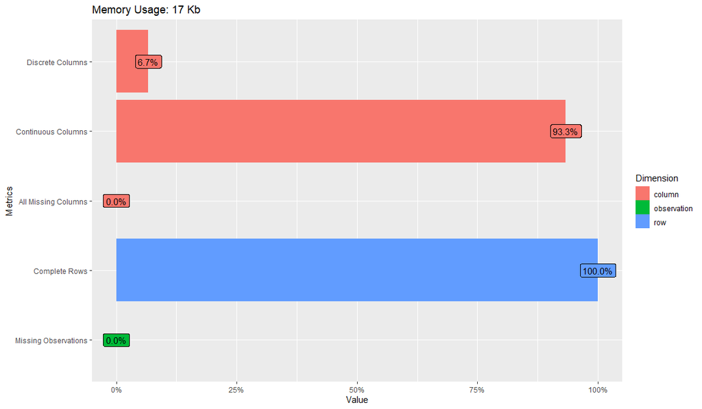

## Perfil dos valores ausentes

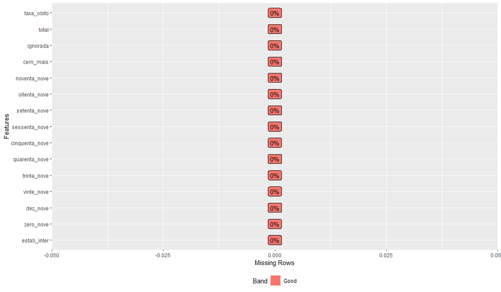

## Correlação entre as variáveis

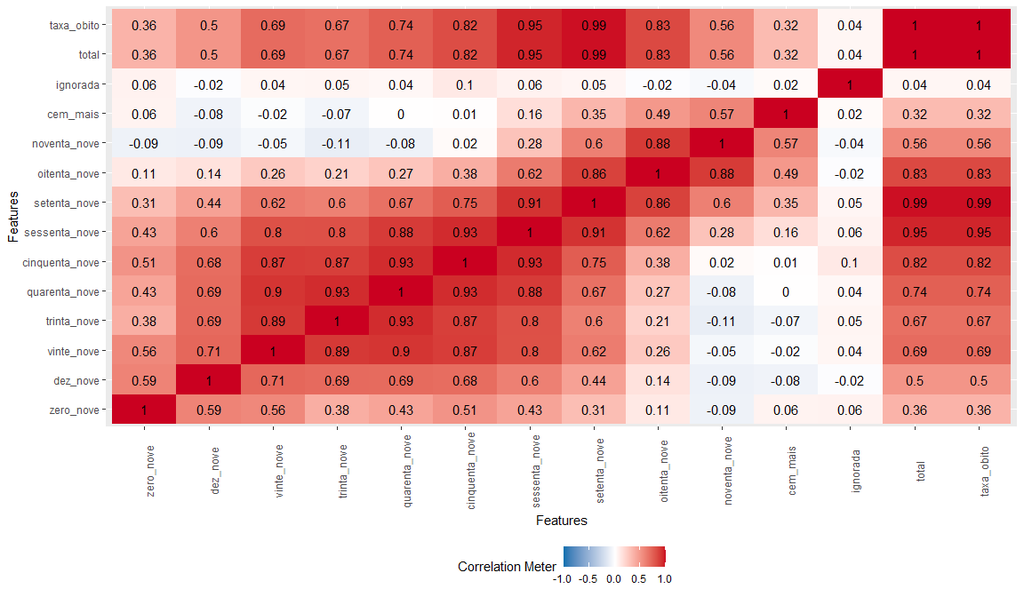

## Distribuição das variáveis quantitativas

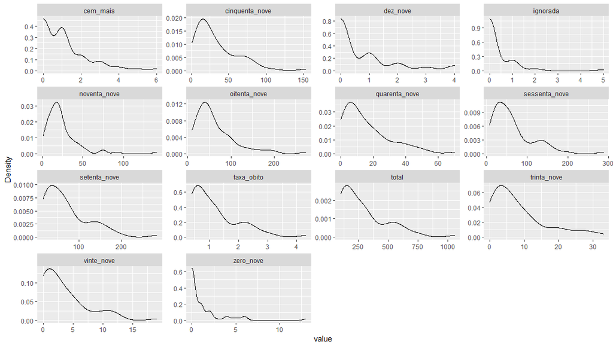

# Preparação dos dados

As variáveis **óbito por outras causas**, **ignorado** e **sem informação** foram excluídas da análise por serem pouco discriminativas, mas foram absorvidas na variável total de internações.

```
##   cinquenta_nove sessenta_nove oitenta_nove noventa_nove total taxa_obito
## 1             55            74           55           23   331  1.3456926
## 2            153           287          162           41  1058  4.3013376
## 3              9            14           54           23   134  0.5447819
## 4             13            21           38           18   126  0.5122576
## 5             11            26           28           10   106  0.4309469
## 6             52           108          194           75   613  2.4921738
```

## Resumo sumário das variáveis

A próxima saída trás os valores de seis medidas (em ordem crescente):

- **Menor valor** (*Min*): o menor valor da variável registrada em algum estabelecimento de internação.
- **Primeiro quartil Q<sub>1</sub>** (*1st Qu*): 25% dos estabelecimentos de internação registraram uma medida da variável abaixo desse valor.
- **Mediana Q<sub>2</sub>** (*median*): 50% dos estabelecimentos de internação registraram uma medida da variável abaixo desse valor.
- **Média** (*mean*): média aritmética dos valores da variável registrada pelos estabelecimentos de internação.
- **Terceiro quartil Q<sub>3</sub>** (*3rd Qu*): 75% dos estabelecimentos de internação registraram uma medida da variável abaixo desse valor.
- **Maior valor** (*Max*): o maior valor da variável registrada em algum estabelecimento de internação.

```
##  cinquenta_nove   sessenta_nove     oitenta_nove     noventa_nove
##  Min.   :  1.00   Min.   :  8.00   Min.   : 10.00   Min.   :  1.00
##  1st Qu.: 13.00   1st Qu.: 27.75   1st Qu.: 32.25   1st Qu.: 12.00
##  Median : 23.00   Median : 48.50   Median : 47.50   Median : 19.00
##  Mean   : 33.96   Mean   : 64.75   Mean   : 64.16   Mean   : 24.60
##  3rd Qu.: 47.25   3rd Qu.: 78.25   3rd Qu.: 87.50   3rd Qu.: 28.25
##  Max.   :153.00   Max.   :287.00   Max.   :273.00   Max.   :141.00
##      total          taxa_obito
##  Min.   : 101.0   Min.   :0.4106
##  1st Qu.: 131.2   1st Qu.:0.5336
##  Median : 239.0   Median :0.9717
##  Mean   : 291.4   Mean   :1.1848
##  3rd Qu.: 367.0   3rd Qu.:1.4921
##  Max.   :1058.0   Max.   :4.3013
```

À guisa de exemplo, considere a variável **taxa de óbito**:

Em 2020, foram registradas 109.961 casos de COVID 19 SRAG no [TABNET](http://tabnet.saude.prefeitura.sp.gov.br/cgi/tabcgi.exe?secretarias/saude/TABNET/RSRAG/sragh.def), dos quais, 24.581 casos evoluíram para óbito (taxa de óbito = 22.35%)

Estas informações podem ser visualizadas no seguinte *boxplot*.

### *Boxplot* da taxa de óbitos

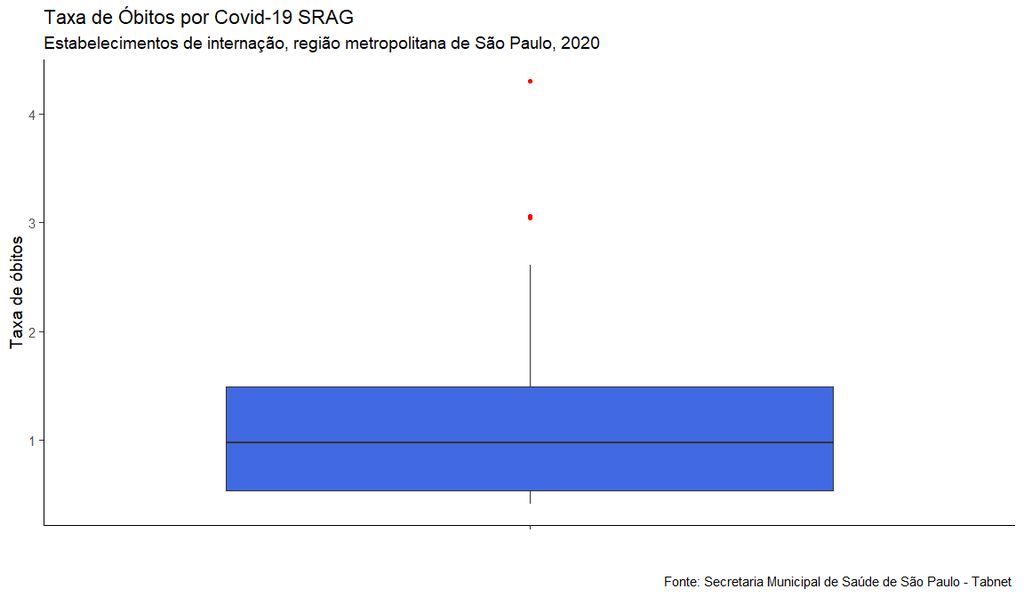

#### Pesquisa de *outliers*

[output not shown]

| estab_inter | total |
| --- | --- |
| 2077574 CONJUNTO HOSPITALAR DO MANDAQUI SAO PAULO | 331 |
| 2078015 HC DA FMUSP HOSPITAL DAS CLINICAS SAO PAULO | 1058 |
| 2079089 HOSP 9 DE JULHO | 134 |
| 2089238 HOSP ALVORADA | 126 |
| 2075962 HOSP DA STA CASA DE STO AMARO | 106 |
| 2058502 HOSP DO SERV PUB EST FCO MORATO DE OLIVEIRA SAO PAULO | 613 |
| 2752077 HOSP DO SERV PUB MUNICIPAL HSPM | 128 |
| 2080796 HOSP MAT SAO CRISTOVAO | 113 |
| 2078589 HOSP MAT STA MARIA-CRUZ AZUL | 232 |
| 3045625 HOSP MAT VIDAS | 136 |
| 5420938 HOSP MUN CARMEN PRUDENTE | 370 |
| 2084139 HOSP MUN DR BENEDICTO MONTENEGRO | 124 |
| 2080346 HOSP MUN DR CARMINO CARICCHIO | 366 |
| 2084473 HOSP MUN DR IGNACIO PROENCA DE GOUVEA | 281 |
| 2077450 HOSP MUN DR JOSE SOARES HUNGRIA | 308 |
| 2786680 HOSP MUN FERNANDO MAURO PIRES DA ROCHA | 106 |
| 7711980 HOSP MUN GILSON DE CASSIA MARQUES DE CARVALHO | 132 |
| 2081970 HOSP MUN JABAQUARA ARTUR RIBEIRO DE SABOYA | 199 |
| 9465464 HOSP MUN JOSANIAS CASTANHA BRAGA | 471 |
| 5718368 HOSP MUN M BOI MIRIM | 545 |
| 2077639 HOSP MUN PROF DR WALDOMIRO DE PAULA | 492 |
| 2082829 HOSP MUN PROFESSOR DOUTOR ALIPIO CORREA NETTO | 119 |
| 2080583 HOSP MUN TIDE SETUBAL | 536 |
| 2080788 HOSP MUN V NHOCUNE ALEXANDRE ZAIO | 172 |
| 3212130 HOSP MUN VER JOSE STOROPOLLI | 261 |
| 2079127 HOSP SIRIO LIBANES | 107 |
| 2688603 HOSP STA CATARINA | 115 |
| 2082624 HOSP STA CRUZ | 105 |
| 2077477 HOSP STA MARCELINA SAO PAULO | 748 |
| 2077507 HOSPITAL BANDEIRANTES | 278 |
| 2080575 HOSPITAL BP | 205 |
| 6938876 HOSPITAL E MATERNIDADE INTERMEDICA ABC | 137 |
| 2091585 HOSPITAL ESTADUAL DE SAPOPEMBA SAO PAULO | 289 |
| 2077426 HOSPITAL ESTADUAL DE VILA ALPINA ORG SOCIAL SECONCI SAO PAUL | 642 |
| 2066092 HOSPITAL GERAL DE PEDREIRA | 611 |
| 2077493 HOSPITAL GERAL DE SAO MATEUS SAO PAULO | 155 |
| 2688573 HOSPITAL GERAL DE VILA NOVA CACHOEIRINHA SAO PAULO | 269 |
| 2091755 HOSPITAL GERAL DE VILA PENTEADO DR JOSE PANGELLA SAO PAULO | 627 |
| 2077671 HOSPITAL GERAL DO GRAJAU PROF LIBER JOHN ALPHONSE DI DIO SP | 244 |
| 2079240 HOSPITAL GERAL JESUS TEIXEIRA DA COSTA GUAIANASES SAO PAULO | 287 |
| 2077620 HOSPITAL GERAL SANTA MARCELINA DE ITAIM PAULISTA SAO PAULO | 256 |
| 2084333 HOSPITAL IGESP | 237 |
| 2058391 HOSPITAL ISRAELITA ALBERT EINSTEIN | 124 |
| 2082225 HOSPITAL KATIA DE SOUZA RODRIGUES TAIPASSP SAO PAULO | 290 |
| 0102075 HOSPITAL MUNICIPAL BELA VISTA | 344 |
| 0102105 HOSPITAL MUNICIPAL BRASILANDIA | 241 |
| 0161438 HOSPITAL MUNICIPAL GUARAPIRANGA | 171 |
| 2076950 HOSPITAL OSWALDO CRUZ | 118 |
| 2091313 HOSPITAL REGIONAL SUL SAO PAULO | 158 |
| 9554157 HOSPITAL SALVALUS | 545 |
| 9684948 HOSPITAL SAMARITANO PAULISTA | 135 |
| 9131434 HOSPITAL SANCTA MAGGIORE HIGIENOPOLIS | 531 |
| 7174713 HOSPITAL SANCTA MAGGIORE MOOCA | 337 |
| 7174721 HOSPITAL SANCTA MAGGIORE PARAISO | 752 |
| 7357079 HOSPITAL SANCTA MAGGIORE PINHEIROS | 415 |
| 7676484 HOSPITAL SANTA CLARA | 184 |
| 2688565 HOSPITAL SAO CAMILO POMPEIA | 129 |
| 3039420 HOSPITAL SAO CAMILO SANTANA | 106 |
| 2077485 HOSPITAL SAO PAULO HOSPITAL DE ENSINO DA UNIFESP SAO PAULO | 546 |
| 2088495 INSTITUTO DANTE PAZZANESE DE CARDIOLOGIA IDPC SAO PAULO | 133 |
| 2028840 INSTITUTO DE INFECTOLOGIA EMILIO RIBAS SAO PAULO | 158 |
| 2688689 SANTA CASA DE SAO PAULO HOSPITAL CENTRAL SAO PAULO | 499 |
| 2077523 UNIDADE DE GESTAO ASSISTENCIAL II HOSPITAL IPIRANGA SP | 275 |
| 7479387 UPA III NOVA CAMPO LIMPO | 318 |
| 9997091 UPA JACANA | 126 |
| 2069032 UPA JULIO TUPY | 101 |
| 6146341 UPA PIRITUBA | 183 |
| 9736700 UPA TITO LOPES | 127 |

| estab_inter | total |
| --- | --- |

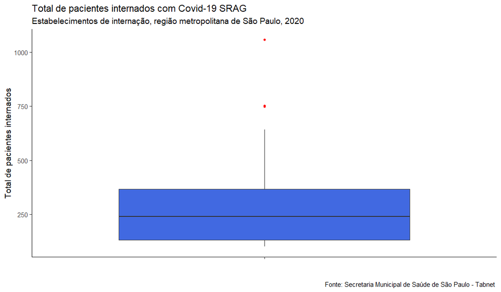

#### Presença de *outliers*

```
## [1] 1058  748  752
```

| estab_inter | total |
| --- | --- |
| 2078015 HC DA FMUSP HOSPITAL DAS CLINICAS SAO PAULO | 1058 |
| 2077477 HOSP STA MARCELINA SAO PAULO | 748 |
| 7174721 HOSPITAL SANCTA MAGGIORE PARAISO | 752 |

Observa-se a presença de 3 estabelecimentos (4.41%) que registraram um número total de internações acima do padrão geral (*outliers*) em 2020.

## Padronização dos dados 2020

A utilização de variáveis com medidas e ou escalas diferentes podem distorcer a estrutura do *cluster*. Variáveis com maior dispersão têm maior peso para o cálculo das medidas de distância do que as demais.

A padronização dos dados faz com que seja atribuído o mesmo peso para cada variável. Neste estudo foi utilizada a transformação de cada variável em escore padrão (*Z score*). O método Z score padroniza cada variável de modo a apresentar uma média zero(0)e desvio padrão um (1):

$$Z = \frac{(x - média)}{desvio \ padrão}$$

```
##      cinquenta_nove sessenta_nove oitenta_nove noventa_nove      total
## [1,]      0.7186164     0.1762649   -0.1842372  -0.07094385  0.1965397
## [2,]      4.0651293     4.2351225    1.9674638   0.72571004  3.8071451
## [3,]     -0.8521957    -0.9670752   -0.2043465  -0.07094385 -0.7818499
## [4,]     -0.7156034    -0.8336855   -0.5260962  -0.29223660 -0.8215814
## [5,]     -0.7838996    -0.7384072   -0.7271898  -0.64630500 -0.9209103
## [6,]      0.6161722     0.8241577    2.6109631   2.23050073  1.5970772
##      taxa_obito
## [1,]  0.1965397
## [2,]  3.8071451
## [3,] -0.7818499
## [4,] -0.8215814
## [5,] -0.9209103
## [6,]  1.5970772
```

# Modelagem estatística

> A partir do conceito filosófico de verissimilitude (MEEHL, apud (CHIN, 2010), os modelos perfeitos inexistem e variam no grau em que se assemelham à realidade que se propõem representar. Isto pode ser analisado sob duas perspectivas: a incompletude (*incompleteness*), que trata do quão bem as complexidades do mundo real são representadas pelo modelo, e a inexatidão (*falseness*), que explora como as contradições entre o modelo e o mundo real são adequadamente expressas (CHIN, 2010). Cabe, pois, ao pesquisador, segundo essa concepção, não questionar se o modelo é verídico, mas como ele é autêntico e em que extensão ele se aproxima da realidade (ROZEBOOM, 2005).

> Antonio Sergio da Silva (SILVA, 2014)

## Método *K-means*

O algoritmo *K-means* é o algoritmo de agrupamento particional mais utilizado baseado no critério da soma dos quadrados (KASSAMBARA, 2017; MACQUEEN, 1967). Trata-se de um algoritmo simples, fácil de implementação e implementado em quase todos os *softwares* de mineração de dados. Ademais, é muito versátil, considerando os aspectos inicialização, distância, função, critério de finalização.

À guisa de exemplo, considere uma classificação de imagens de animais. Uma questão importante poderia ser a imagem de um cão. Qualquer imagem que se pareça com um cão ou partes de um cão, será classificado neste *cluster*. Imagens de peixes e aves ficarão distantes desta classificação e aparecerão em outros *clusters*.

## Determinação do número de *clusters*

O método *k-means* é um procedimento não hierárquico para agrupar indivíduos, cujo número inicial de *clusters* é definido pelo pesquisador (FÁVERO; BELFIORE, 2017; KASSAMBARA, 2017).

A análise visual a partir de um gráfico de linhas de duas dimensões: os *K Clusters* (*Number of clusters k*) e a Soma dos Quadrados dos Erros de Predição (*Total Within Sum of Square - SSE*) sugere um número inicial de *clusters* para ser usado. O SSE resulta na variância e desvio padrão (inércia) dos dados da base utilizada. Desta forma pode-se visualizar o valor de quão próximo os dados estão uns dos outros. Quanto menor for o número de *clusters*, maior será o valor dessa inércia (KASSAMBARA, 2017).

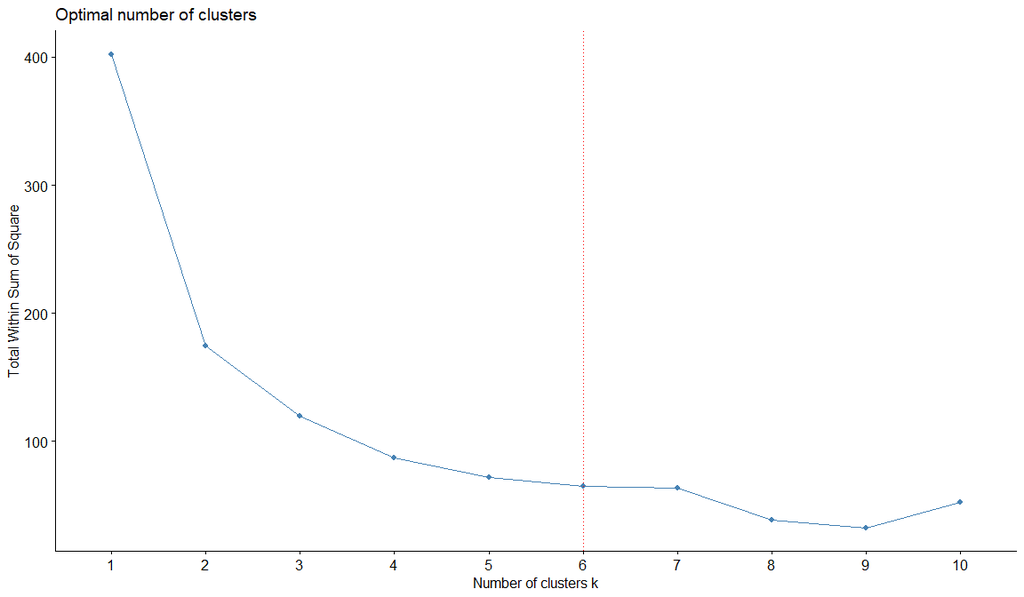

Sendo assim, a quantidade de cinco ou seis *clusters* parece ser um número bem interessante para se aplicar nesse conjunto de dados.

## Visualização gráfica dos *clusters*

O algoritmo para determinar a alocação das observações em cada conglomerado é denominado *nearest centroid sorting*. O *K-means* usa a distância euclidiana como critério de distância para formar os grupos.

A função `fviz_cluster()` do pacote `fatoextra` pode ser usada para visualizar facilmente os *clusters k-means*. No gráfico resultante, as observações são representadas por pontos, usando análise de componentes principais (PCA) quando o número de variáveis x<sub>ij</sub>for maior do que 2 (KASSAMBARA, 2017).

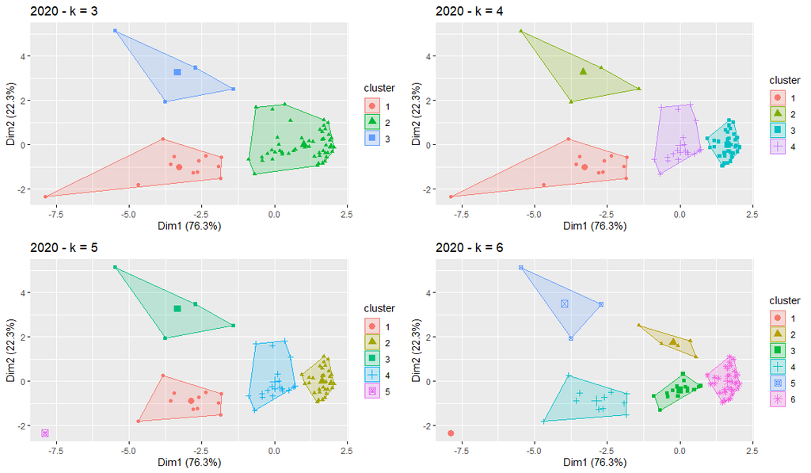

## Agrupar *cluster* e base

|  | estab_inter | zero_nove | dez_nove | vinte_nove | trinta_nove | quarenta_nove | cinquenta_nove | sessenta_nove | setenta_nove | oitenta_nove | noventa_nove | cem_mais | ignorada | total | taxa_obito | idade20.k4.cluster |
| --- | --- | --- | --- | --- | --- | --- | --- | --- | --- | --- | --- | --- | --- | --- | --- | --- |
| 2 | 2078015 HC DA FMUSP HOSPITAL DAS CLINICAS SAO PAULO | 5 | 4 | 19 | 33 | 70 | 153 | 287 | 282 | 162 | 41 | 1 | 1 | 1058 | 0.0430134 | 1 |
| 19 | 9465464 HOSP MUN JOSANIAS CASTANHA BRAGA | 0 | 0 | 4 | 21 | 37 | 70 | 124 | 105 | 90 | 19 | 1 | 0 | 471 | 0.0191487 | 1 |
| 20 | 5718368 HOSP MUN M BOI MIRIM | 1 | 1 | 4 | 15 | 32 | 76 | 159 | 145 | 89 | 22 | 1 | 0 | 545 | 0.0221572 | 1 |
| 21 | 2077639 HOSP MUN PROF DR WALDOMIRO DE PAULA | 1 | 2 | 11 | 27 | 39 | 63 | 102 | 129 | 93 | 24 | 1 | 0 | 492 | 0.0200024 | 1 |
| 23 | 2080583 HOSP MUN TIDE SETUBAL | 1 | 1 | 12 | 21 | 45 | 61 | 134 | 134 | 91 | 33 | 3 | 0 | 536 | 0.0217913 | 1 |
| 29 | 2077477 HOSP STA MARCELINA SAO PAULO | 6 | 4 | 12 | 31 | 54 | 109 | 199 | 176 | 134 | 20 | 3 | 0 | 748 | 0.0304102 | 1 |
| 34 | 2077426 HOSPITAL ESTADUAL DE VILA ALPINA ORG SOCIAL SECONCI SAO PAUL | 6 | 0 | 8 | 8 | 31 | 73 | 139 | 162 | 167 | 46 | 2 | 0 | 642 | 0.0261007 | 1 |
| 35 | 2066092 HOSPITAL GERAL DE PEDREIRA | 5 | 2 | 10 | 20 | 39 | 84 | 151 | 144 | 113 | 43 | 0 | 0 | 611 | 0.0248404 | 1 |
| 38 | 2091755 HOSPITAL GERAL DE VILA PENTEADO DR JOSE PANGELLA SAO PAULO | 0 | 1 | 9 | 19 | 47 | 84 | 171 | 150 | 107 | 37 | 2 | 0 | 627 | 0.0254909 | 1 |
| 50 | 9554157 HOSPITAL SALVALUS | 0 | 3 | 6 | 26 | 37 | 75 | 135 | 139 | 90 | 34 | 0 | 0 | 545 | 0.0221572 | 1 |
| 59 | 2077485 HOSPITAL SAO PAULO HOSPITAL DE ENSINO DA UNIFESP SAO PAULO | 6 | 4 | 11 | 19 | 36 | 91 | 144 | 118 | 90 | 27 | 0 | 0 | 546 | 0.0221978 | 1 |
| 62 | 2688689 SANTA CASA DE SAO PAULO HOSPITAL CENTRAL SAO PAULO | 2 | 4 | 12 | 28 | 48 | 72 | 132 | 122 | 66 | 11 | 1 | 1 | 499 | 0.0202870 | 1 |
| 6 | 2058502 HOSP DO SERV PUB EST FCO MORATO DE OLIVEIRA SAO PAULO | 0 | 0 | 0 | 2 | 5 | 52 | 108 | 174 | 194 | 75 | 3 | 0 | 613 | 0.0249217 | 2 |
| 52 | 9131434 HOSPITAL SANCTA MAGGIORE HIGIENOPOLIS | 0 | 0 | 0 | 0 | 3 | 9 | 67 | 159 | 195 | 92 | 6 | 0 | 531 | 0.0215880 | 2 |
| 54 | 7174721 HOSPITAL SANCTA MAGGIORE PARAISO | 0 | 0 | 0 | 1 | 1 | 14 | 120 | 198 | 273 | 141 | 3 | 1 | 752 | 0.0305728 | 2 |
| 55 | 7357079 HOSPITAL SANCTA MAGGIORE PINHEIROS | 0 | 0 | 0 | 0 | 4 | 10 | 58 | 129 | 136 | 74 | 4 | 0 | 415 | 0.0168720 | 2 |
| 3 | 2079089 HOSP 9 DE JULHO | 0 | 0 | 0 | 0 | 2 | 9 | 14 | 32 | 54 | 23 | 0 | 0 | 134 | 0.0054478 | 3 |
| 4 | 2089238 HOSP ALVORADA | 2 | 0 | 0 | 2 | 5 | 13 | 21 | 25 | 38 | 18 | 2 | 0 | 126 | 0.0051226 | 3 |
| 5 | 2075962 HOSP DA STA CASA DE STO AMARO | 0 | 0 | 0 | 2 | 7 | 11 | 26 | 21 | 28 | 10 | 1 | 0 | 106 | 0.0043095 | 3 |
| 7 | 2752077 HOSP DO SERV PUB MUNICIPAL HSPM | 1 | 0 | 1 | 6 | 4 | 23 | 34 | 33 | 15 | 5 | 1 | 5 | 128 | 0.0052039 | 3 |
| 8 | 2080796 HOSP MAT SAO CRISTOVAO | 0 | 0 | 2 | 4 | 7 | 6 | 13 | 19 | 44 | 17 | 1 | 0 | 113 | 0.0045941 | 3 |
| 10 | 3045625 HOSP MAT VIDAS | 2 | 2 | 5 | 6 | 20 | 33 | 37 | 17 | 10 | 4 | 0 | 0 | 136 | 0.0055291 | 3 |
| 12 | 2084139 HOSP MUN DR BENEDICTO MONTENEGRO | 0 | 0 | 1 | 5 | 8 | 14 | 27 | 28 | 28 | 13 | 0 | 0 | 124 | 0.0050413 | 3 |
| 16 | 2786680 HOSP MUN FERNANDO MAURO PIRES DA ROCHA | 2 | 0 | 2 | 3 | 7 | 18 | 22 | 23 | 22 | 6 | 0 | 1 | 106 | 0.0043095 | 3 |
| 17 | 7711980 HOSP MUN GILSON DE CASSIA MARQUES DE CARVALHO | 1 | 0 | 0 | 3 | 6 | 23 | 46 | 39 | 12 | 2 | 0 | 0 | 132 | 0.0053665 | 3 |
| 18 | 2081970 HOSP MUN JABAQUARA ARTUR RIBEIRO DE SABOYA | 1 | 0 | 5 | 7 | 13 | 22 | 47 | 49 | 38 | 16 | 1 | 0 | 199 | 0.0080904 | 3 |
| 22 | 2082829 HOSP MUN PROFESSOR DOUTOR ALIPIO CORREA NETTO | 2 | 3 | 2 | 5 | 11 | 14 | 20 | 24 | 30 | 8 | 0 | 0 | 119 | 0.0048380 | 3 |
| 24 | 2080788 HOSP MUN V NHOCUNE ALEXANDRE ZAIO | 0 | 0 | 3 | 5 | 6 | 17 | 30 | 50 | 42 | 17 | 1 | 1 | 172 | 0.0069927 | 3 |
| 26 | 2079127 HOSP SIRIO LIBANES | 1 | 0 | 0 | 1 | 0 | 1 | 8 | 24 | 40 | 32 | 0 | 0 | 107 | 0.0043501 | 3 |
| 27 | 2688603 HOSP STA CATARINA | 0 | 0 | 0 | 2 | 2 | 3 | 12 | 17 | 35 | 39 | 5 | 0 | 115 | 0.0046754 | 3 |
| 28 | 2082624 HOSP STA CRUZ | 0 | 0 | 1 | 2 | 2 | 9 | 22 | 20 | 33 | 15 | 1 | 0 | 105 | 0.0042688 | 3 |
| 31 | 2080575 HOSPITAL BP | 0 | 1 | 0 | 4 | 5 | 22 | 35 | 66 | 46 | 25 | 1 | 0 | 205 | 0.0083343 | 3 |
| 32 | 6938876 HOSPITAL E MATERNIDADE INTERMEDICA ABC | 0 | 0 | 2 | 4 | 12 | 35 | 46 | 20 | 11 | 6 | 1 | 0 | 137 | 0.0055698 | 3 |
| 36 | 2077493 HOSPITAL GERAL DE SAO MATEUS SAO PAULO | 3 | 0 | 3 | 7 | 15 | 22 | 36 | 35 | 24 | 9 | 1 | 0 | 155 | 0.0063016 | 3 |
| 43 | 2058391 HOSPITAL ISRAELITA ALBERT EINSTEIN | 0 | 1 | 1 | 1 | 1 | 7 | 9 | 33 | 38 | 32 | 1 | 0 | 124 | 0.0050413 | 3 |
| 47 | 0161438 HOSPITAL MUNICIPAL GUARAPIRANGA | 0 | 0 | 3 | 7 | 11 | 25 | 44 | 48 | 26 | 7 | 0 | 0 | 171 | 0.0069521 | 3 |
| 48 | 2076950 HOSPITAL OSWALDO CRUZ | 0 | 0 | 0 | 0 | 4 | 4 | 14 | 23 | 49 | 23 | 1 | 0 | 118 | 0.0047973 | 3 |
| 49 | 2091313 HOSPITAL REGIONAL SUL SAO PAULO | 4 | 0 | 1 | 9 | 10 | 16 | 50 | 41 | 23 | 4 | 0 | 0 | 158 | 0.0064235 | 3 |
| 51 | 9684948 HOSPITAL SAMARITANO PAULISTA | 0 | 0 | 2 | 4 | 7 | 14 | 21 | 30 | 39 | 17 | 1 | 0 | 135 | 0.0054885 | 3 |
| 56 | 7676484 HOSPITAL SANTA CLARA | 0 | 0 | 0 | 5 | 5 | 13 | 44 | 57 | 41 | 19 | 0 | 0 | 184 | 0.0074806 | 3 |
| 57 | 2688565 HOSPITAL SAO CAMILO POMPEIA | 0 | 0 | 2 | 2 | 2 | 9 | 19 | 30 | 39 | 25 | 1 | 0 | 129 | 0.0052445 | 3 |
| 58 | 3039420 HOSPITAL SAO CAMILO SANTANA | 0 | 1 | 0 | 2 | 5 | 9 | 15 | 30 | 25 | 19 | 0 | 0 | 106 | 0.0043095 | 3 |
| 60 | 2088495 INSTITUTO DANTE PAZZANESE DE CARDIOLOGIA IDPC SAO PAULO | 0 | 0 | 0 | 2 | 6 | 16 | 28 | 50 | 29 | 2 | 0 | 0 | 133 | 0.0054072 | 3 |
| 61 | 2028840 INSTITUTO DE INFECTOLOGIA EMILIO RIBAS SAO PAULO | 0 | 0 | 4 | 6 | 15 | 31 | 52 | 36 | 13 | 1 | 0 | 0 | 158 | 0.0064235 | 3 |
| 65 | 9997091 UPA JACANA | 1 | 1 | 1 | 6 | 9 | 24 | 31 | 21 | 19 | 13 | 0 | 0 | 126 | 0.0051226 | 3 |
| 66 | 2069032 UPA JULIO TUPY | 0 | 1 | 1 | 4 | 5 | 12 | 22 | 24 | 21 | 9 | 2 | 0 | 101 | 0.0041062 | 3 |
| 67 | 6146341 UPA PIRITUBA | 0 | 1 | 2 | 5 | 13 | 18 | 44 | 44 | 44 | 12 | 0 | 0 | 183 | 0.0074399 | 3 |
| 68 | 9736700 UPA TITO LOPES | 0 | 0 | 0 | 2 | 13 | 21 | 29 | 27 | 28 | 6 | 0 | 1 | 127 | 0.0051632 | 3 |
| 1 | 2077574 CONJUNTO HOSPITALAR DO MANDAQUI SAO PAULO | 4 | 2 | 6 | 11 | 13 | 55 | 74 | 88 | 55 | 23 | 0 | 0 | 331 | 0.0134569 | 4 |
| 9 | 2078589 HOSP MAT STA MARIA-CRUZ AZUL | 1 | 0 | 3 | 1 | 3 | 15 | 24 | 64 | 87 | 34 | 0 | 0 | 232 | 0.0094320 | 4 |
| 11 | 5420938 HOSP MUN CARMEN PRUDENTE | 13 | 3 | 10 | 13 | 24 | 62 | 101 | 87 | 43 | 11 | 2 | 1 | 370 | 0.0150425 | 4 |
| 13 | 2080346 HOSP MUN DR CARMINO CARICCHIO | 0 | 1 | 5 | 16 | 24 | 68 | 76 | 81 | 68 | 24 | 1 | 2 | 366 | 0.0148799 | 4 |
| 14 | 2084473 HOSP MUN DR IGNACIO PROENCA DE GOUVEA | 0 | 0 | 8 | 25 | 22 | 31 | 71 | 60 | 46 | 18 | 0 | 0 | 281 | 0.0114242 | 4 |
| 15 | 2077450 HOSP MUN DR JOSE SOARES HUNGRIA | 0 | 1 | 3 | 12 | 25 | 42 | 79 | 80 | 53 | 13 | 0 | 0 | 308 | 0.0125219 | 4 |
| 25 | 3212130 HOSP MUN VER JOSE STOROPOLLI | 1 | 0 | 6 | 11 | 15 | 47 | 52 | 60 | 49 | 19 | 0 | 1 | 261 | 0.0106111 | 4 |
| 30 | 2077507 HOSPITAL BANDEIRANTES | 0 | 0 | 1 | 1 | 3 | 11 | 44 | 67 | 97 | 51 | 2 | 1 | 278 | 0.0113022 | 4 |
| 33 | 2091585 HOSPITAL ESTADUAL DE SAPOPEMBA SAO PAULO | 0 | 0 | 2 | 7 | 9 | 21 | 59 | 85 | 84 | 21 | 1 | 0 | 289 | 0.0117494 | 4 |
| 37 | 2688573 HOSPITAL GERAL DE VILA NOVA CACHOEIRINHA SAO PAULO | 0 | 1 | 2 | 9 | 20 | 35 | 71 | 58 | 53 | 20 | 0 | 0 | 269 | 0.0109363 | 4 |
| 39 | 2077671 HOSPITAL GERAL DO GRAJAU PROF LIBER JOHN ALPHONSE DI DIO SP | 4 | 2 | 3 | 10 | 20 | 32 | 47 | 63 | 44 | 16 | 3 | 0 | 244 | 0.0099199 | 4 |
| 40 | 2079240 HOSPITAL GERAL JESUS TEIXEIRA DA COSTA GUAIANASES SAO PAULO | 0 | 0 | 5 | 11 | 15 | 48 | 61 | 62 | 59 | 25 | 1 | 0 | 287 | 0.0116681 | 4 |
| 41 | 2077620 HOSPITAL GERAL SANTA MARCELINA DE ITAIM PAULISTA SAO PAULO | 2 | 2 | 4 | 11 | 20 | 33 | 57 | 63 | 52 | 12 | 0 | 0 | 256 | 0.0104078 | 4 |
| 42 | 2084333 HOSPITAL IGESP | 0 | 0 | 0 | 2 | 3 | 6 | 28 | 55 | 86 | 55 | 2 | 0 | 237 | 0.0096353 | 4 |
| 44 | 2082225 HOSPITAL KATIA DE SOUZA RODRIGUES TAIPASSP SAO PAULO | 1 | 1 | 6 | 14 | 26 | 42 | 68 | 57 | 51 | 22 | 2 | 0 | 290 | 0.0117901 | 4 |
| 45 | 0102075 HOSPITAL MUNICIPAL BELA VISTA | 0 | 0 | 2 | 8 | 28 | 44 | 89 | 94 | 64 | 12 | 1 | 2 | 344 | 0.0139854 | 4 |
| 46 | 0102105 HOSPITAL MUNICIPAL BRASILANDIA | 0 | 0 | 4 | 9 | 18 | 23 | 57 | 69 | 46 | 14 | 1 | 0 | 241 | 0.0097979 | 4 |
| 53 | 7174713 HOSPITAL SANCTA MAGGIORE MOOCA | 0 | 0 | 0 | 1 | 0 | 8 | 59 | 92 | 131 | 46 | 0 | 0 | 337 | 0.0137009 | 4 |
| 63 | 2077523 UNIDADE DE GESTAO ASSISTENCIAL II HOSPITAL IPIRANGA SP | 2 | 0 | 2 | 6 | 16 | 35 | 60 | 67 | 55 | 27 | 4 | 1 | 275 | 0.0111802 | 4 |
| 64 | 7479387 UPA III NOVA CAMPO LIMPO | 1 | 1 | 5 | 11 | 21 | 41 | 78 | 76 | 66 | 17 | 0 | 1 | 318 | 0.0129284 | 4 |

## Resumo do modelo 2020

### Média aritmética

| idade20.k4$cluster | zero_nove | dez_nove | vinte_nove | trinta_nove | quarenta_nove | cinquenta_nove | sessenta_nove | setenta_nove | oitenta_nove | noventa_nove | cem_mais | total | taxa_obito |
| --- | --- | --- | --- | --- | --- | --- | --- | --- | --- | --- | --- | --- | --- |
| 1 | 2.750 | 2.166667 | 9.833333 | 22.33333 | 42.91667 | 84.2500 | 156.4167 | 150.500 | 107.6667 | 29.7500 | 1.2500 | 610.000 | 0.0247998 |
| 2 | 0.000 | 0.000000 | 0.000000 | 0.75000 | 3.25000 | 21.2500 | 88.2500 | 165.000 | 199.5000 | 95.5000 | 4.0000 | 577.750 | 0.0234886 |
| 3 | 0.625 | 0.343750 | 1.375000 | 3.84375 | 7.43750 | 16.0625 | 28.6875 | 32.375 | 30.7500 | 14.1875 | 0.6875 | 136.625 | 0.0055545 |
| 4 | 1.450 | 0.700000 | 3.850000 | 9.45000 | 16.25000 | 34.9500 | 62.7500 | 71.400 | 64.4500 | 24.0000 | 1.0000 | 290.700 | 0.0118185 |

### Desvio padrão

| idade20.k4$cluster | zero_nove | dez_nove | vinte_nove | trinta_nove | quarenta_nove | cinquenta_nove | sessenta_nove | setenta_nove | oitenta_nove | noventa_nove | cem_mais | total | taxa_obito |
| --- | --- | --- | --- | --- | --- | --- | --- | --- | --- | --- | --- | --- | --- |
| 1 | 2.598076 | 1.5859229 | 4.130449 | 7.0496078 | 10.925020 | 25.244711 | 47.80730 | 45.67972 | 31.20120 | 10.913919 | 1.0552897 | 160.86414 | 0.0065400 |
| 2 | 0.000000 | 0.0000000 | 0.000000 | 0.9574271 | 1.707825 | 20.613507 | 30.35759 | 28.87906 | 56.22870 | 31.437769 | 1.4142136 | 141.74949 | 0.0057629 |
| 3 | 1.039541 | 0.7006621 | 1.475608 | 2.2448418 | 4.737888 | 8.511615 | 12.98246 | 12.54090 | 11.81033 | 9.606575 | 0.9979818 | 28.45681 | 0.0011569 |
| 4 | 2.999561 | 0.9233805 | 2.580799 | 5.7443336 | 8.546314 | 17.261076 | 18.69949 | 12.71303 | 22.31703 | 12.908585 | 1.1697953 | 42.09526 | 0.0017114 |

### Coeficiente de variação

| idade20.k4$cluster | zero_nove | dez_nove | vinte_nove | trinta_nove | quarenta_nove | cinquenta_nove | sessenta_nove | setenta_nove | oitenta_nove | noventa_nove | cem_mais | total | taxa_obito |
| --- | --- | --- | --- | --- | --- | --- | --- | --- | --- | --- | --- | --- | --- |
| 1 | 94.4755 | 73.19644 | 42.00456 | 31.56541 | 25.45636 | 29.96405 | 30.56407 | 30.35197 | 28.97945 | 36.68544 | 84.42318 | 26.37117 | 26.37117 |
| 2 | NaN | NaN | NaN | 127.65695 | 52.54847 | 97.00474 | 34.39954 | 17.50246 | 28.18481 | 32.91913 | 35.35534 | 24.53474 | 24.53474 |
| 3 | 166.3265 | 203.82898 | 107.31695 | 58.40239 | 63.70269 | 52.99060 | 45.25477 | 38.73637 | 38.40757 | 67.71154 | 145.16099 | 20.82841 | 20.82841 |
| 4 | 206.8663 | 131.91150 | 67.03375 | 60.78660 | 52.59270 | 49.38791 | 29.79999 | 17.80536 | 34.62689 | 53.78577 | 116.97953 | 14.48065 | 14.48065 |

## Validação interna do agrupamento

A validação de agrupamento consiste em projetar o procedimento de avaliação da qualidade dos resultados do algoritmo de agrupamento.

Isso é importante para evitar encontrar padrões em dados aleatórios, bem como na situação em que se deseja a comparação entre dois algoritmos de agrupamento (KASSAMBARA, 2017).

O processo de validação interna usa as informações internas do processo do agrupamento para avaliar a qualidade de uma estrutura de agrupamento, aquém de informações externas. O processo é capaz de estimar o número de **clusters** e o algoritmo de agrupamento apropriado sem nenhum dado externo (KASSAMBARA, 2017).

Medidas internas usam informações intrínsecas nos dados para avaliar a qualidade do agrupamento (KASSAMBARA, 2017).

As medidas internas incluem a conectividade, o coeficiente de silhueta e o índice de Dunn.

### Conectividade

A conectividade corresponde à medida em que os itens são colocados no mesmo *cluster* que seus vizinhos mais próximos no espaço de dados. A conectividade tem um valor entre 0 e infinito e deve ser minimizada (KASSAMBARA, 2017).

### Coeficiente de silhueta

O coeficiente de silhueta (S_i) mede a semelhança de um indivíduo y<sub>i</sub> com os outros indivíduos em seu próprio *cluster* versus os do *cluster* vizinho (KASSAMBARA, 2017).

Os valores de S_i variam de -1 a +1:

- Um valor de S_i próximo a 1 indica que o indivíduo está bem agrupado. Isto é, o indivíduo y<sub>i</sub> é semelhante aos outros índivíduos em seu grupo (KASSAMBARA, 2017).
- Um valor de S_i próximo a -1 indica que o indivíduo está mal agrupado e que a atribuição a algum outro agrupamento provavelmente melhoraria os resultados gerais (KASSAMBARA, 2017).

[output not shown]

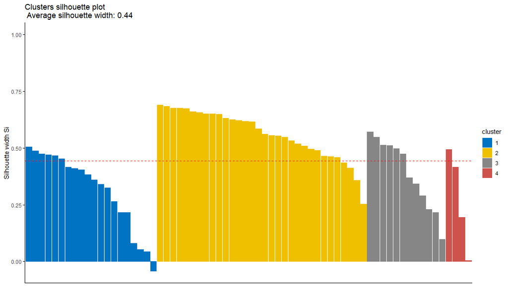

### Coeficientes de silhueta para cada indívíduo y<sub>i</sub>

```
##    cluster neighbor sil_width
## 64       1        2 0.5049813
## 1        1        2 0.4871808
## 44       1        2 0.4747939
## 40       1        2 0.4704019
## 45       1        2 0.4663701
## 15       1        2 0.4536358
## 37       1        2 0.4160225
## 13       1        3 0.4097384
## 63       1        2 0.4051835
## 11       1        2 0.3823309
```

### Indivíduos com Si negativo

```
##    cluster neighbor   sil_width
## 46       1        2 -0.04192129
```

### Índice de Dun

O índice de Dunn identifica *clusters* densos e bem separados. É definida como a razão entre as distâncias mínimas entre os clusters e a distância máxima entre os clusters.

```
## [1] 0.07137595
```

O índice de Dunn tem um valor entre zero e infinito e deve ser maximizado. As pontuações de Dunn com alto valor são mais desejáveis. Nesta análise o valor é muito baixo, sugerindo que não é um bom agrupamento.

## Avaliação simultânea de algoritmos de agrupamento

O pacote `R clValid` (BROCK *et al.*, 2008) compara simultaneamente vários algoritmos de agrupamento em uma única chamada de função para identificar a melhor abordagem de agrupamento e o número ideal de agrupamentos (KASSAMBARA, 2017).

```
##
## Clustering Methods:
##  hierarchical kmeans pam
##
## Cluster sizes:
##  2 3 4 5 6
##
## Validation Measures:
##                                  2       3       4       5       6
##
## hierarchical Connectivity   2.9290  6.0579 12.2306 15.0401 18.3341
##              Dunn           0.3566  0.4565  0.2025  0.3268  0.3268
##              Silhouette     0.6469  0.6146  0.5629  0.5713  0.5333
## kmeans       Connectivity   6.4837 10.1889 18.7179 22.8766 20.2607
##              Dunn           0.1412  0.1806  0.1186  0.1548  0.1073
##              Silhouette     0.5989  0.6092  0.5595  0.4766  0.4813
## pam          Connectivity   9.9008 11.3675 15.6349 17.4429 20.2607
##              Dunn           0.0708  0.0506  0.0628  0.0628  0.1073
##              Silhouette     0.5776  0.4004  0.4423  0.4707  0.4813
##
## Optimal Scores:
##
##              Score  Method       Clusters
## Connectivity 2.9290 hierarchical 2
## Dunn         0.4565 hierarchical 3
## Silhouette   0.6469 hierarchical 2
```

Considerando três métodos de agrupamentos (hierárquico, kmeans e pam), os scores de validação interna (conectivdade, índice de Dunn e o coeficiente de silhueta) sugerem o método hierárquico e a formação de dois *clusters* para esse conjunto de dados.

## Medidas de estabilidade

As medidas de estabilidade avaliam a consistência de um resultado de agrupamento comparando-o com os agrupamentos obtidos após a remoção de cada coluna, um de cada vez (KASSAMBARA, 2017).

As medidas de estabilidade de *cluster* incluem:

- A proporção média de não sobreposição (APN);
- A distância média (AD);
- A distância média entre as médias (amc):
- A figura de mérito (FOM).

O APN, AD e amc são todos baseados no cruzamento tabela de classificação do agrupamento original nos dados completos com o agrupamento baseado na remoção de uma coluna (KASSAMBARA, 2017).

O APN mede a proporção média de indivíduos não colocadas no mesmo *cluster* agrupando com base nos dados completos e agrupando com base nos dados com uma única coluna removida (KASSAMBARA, 2017).

O AD mede a distância média entre os indivíduos colocados no mesmo *cluster* em ambos os casos (conjunto de dados completo e remoção de uma coluna) (KASSAMBARA, 2017).

O amc mede a distância média entre os centros dos *clusters* para indivíduos colocadas no mesmo *cluster* em ambos os casos (KASSAMBARA, 2017).

O FOM mede a variação intracluster média da coluna excluída, em que o agrupamento é baseado nas colunas restantes (não excluídas) (KASSAMBARA, 2017).

Os valores de APN, amc e FOM variam de 0 a 1, com valor menor correspondendo a resultados de agrupamento altamente consistentes. AD tem um valor entre 0 e infinito, e valores menores também são preferidos (KASSAMBARA, 2017).

```
##     Score Method Clusters
## APN  0.01 kmeans        2
## AD   1.28    pam        4
## ADM  0.08    pam        3
## FOM  0.50 kmeans        4
```

## Validação externa do agrupamento

Este processo consiste em comparar os resultados de uma análise de *cluster* com um resultado conhecido externamente, como rótulos de classe fornecidos externamente (KASSAMBARA, 2017).

Ele mede até que ponto os rótulos de **cluster** correspondem aos rótulos de classe fornecidos externamente. Usa-se essa abordagem para selecionar o melhor algoritmo de **cluster** para um conjunto de dados específico (KASSAMBARA, 2017).

O índice de Rand (HUBERT; ARABIE, 1985; RAND, 1971) fornece um valor entre 0 e 1, onde 1 significa que os dois resultados de agrupamento correspondem de forma idêntica.

O índice de Rand corrigido fornece uma medida para avaliar a similaridade entre duas partições, ajustadas ao acaso. Seu intervalo é de -1 (sem concordância) a 1 (concordância perfeita) (KASSAMBARA, 2017).

```
## [1] 1
```

```
## [1] 0
```

# Interpretação e validação dos *clusters*

[figure not shown]

# Referências

HOTHORN; EVERITT (2009)

THULIN (2021)

BROCK, G.; PIHUR, V.; DATTA, S.; DATTA, S. clValid: An R package for cluster validation. **Journal of Statistical Software**, v. 25, p. 1–22, 2008.

CHIN, W. W. How to write up and report PLS analyses. *Em*: **Handbook of partial least squares**. [s.l.] Springer, 2010. p. 655–690.

FÁVERO, L. P.; BELFIORE, P. **Manual de análise de dados: estatı́stica e modelagem multivariada com Excel, SPSS e Stata**. [s.l.] Elsevier Brasil, 2017.

HOTHORN, T.; EVERITT, B. S. **A handbook of statistical analyses using R**. [s.l.] Chapman; Hall/CRC, 2009.

HUBERT, L.; ARABIE, P. Comparing partitions. **Journal of classification**, v. 2, n. 1, p. 193–218, 1985.

KASSAMBARA, A. **Practical guide to cluster analysis in R: Unsupervised machine learning**. [s.l.] Sthda, 2017. v. 1

KAUFMAN, L.; ROUSSEEUW, P. J. **Finding groups in data: an introduction to cluster analysis**. [s.l.] John Wiley & Sons, 2009.

MACQUEEN, J. Classification and analysis of multivariate observations. Em: 5th Berkeley Symp. Math. Statist. Probability, 1967, [...]. 1967. p. 281–297.

RAND, W. M. Objective criteria for the evaluation of clustering methods. **Journal of the American Statistical association**, v. 66, n. 336, p. 846–850, 1971.

ROZEBOOM, W. W. Meehl on metatheory. **Journal of clinical psychology**, v. 61, n. 10, p. 1317–1354, 2005.

SILVA, A. S. da. Um modelo de antecedentes para a cocriação de valores em serviços de geriatria na cidade de São Paulo: Uma aplicação da modelagem de equações estruturais. 2014.

THULIN, M. **Modern Statistics with R: From wrangling and exploring data to inference and predictive modelling**. [s.l.] BoD-Books on Demand, 2021.

VILLAR, J.; BLANCO, J.; KACMAREK, R. M. Current incidence and outcome of the acute respiratory distress syndrome. **Current opinion in critical care**, v. 22, n. 1, p. 1–6, 2016.

VILLAR, J.; SULEMANJI, D.; KACMAREK, R. M. The acute respiratory distress syndrome: incidence and mortality, has it changed? **Current opinion in critical care**, v. 20, n. 1, p. 3–9, 2014.

# Informações de contato

- Web: https://www.preventsenior.com.br
- Email: antonio.sergio@preventsenior.com.br
- Phone: +55 (11) 94040 5357

**Sistema de Gestão da Qualidade, Prevent Senior, 2022.**

A work by [R Markdown](https://rmarkdown.rstudio.com/)

[figure not shown]

RStudio 2022.02.1 Build 461 © 2009-2022 RStudio, PBC.

[figure not shown]

UUID:81772cf4-8de4-467d-9603-4c60345b072c